# Intro to R tutorial

Janice Goh

Run at 2020-09-19 19:02

```r
knitr::opts_chunk$set(echo = TRUE)
```

Welcome to the concept of R environment. Think about this like the facebook game farmville. Initially there's nothing in that virtual environment. You can however, put things into that environment and tell the things what to do e.g. plant a carrot, then harvest it. We do so by using the R language to tell the computer what to do. In this case, we will be adding in our data to this environment. But first, some set up.

# 1 Settings

```r
## uncomment and run installation if packages have not been installed
#install.packages(c("tidyverse", "readxl"))
setwd("~/Documents/IntroToR/")
library(tidyverse)
library(randomNames)
library(readxl)
```

R by itself has some base functions, which in many online forums, will be refered to as base R. However, base R can be clunky at times and hard to read. Thankfully, the R community has come up with extra functions that make coding in R much easier. These functions are stored in libraries, like the ones we just downloaded. One of the most widely used packages is the tidyverse, which helps greatly in data wrangling. We are going to use that package today too.

# 2 Generating data frame for today

```r
set.seed(42)
medications <- data.frame("medications" =
                            c("Amlodipine_5mg", "Metformin_500mg", "Atenolol_50mg",
                              "Metformin_850mg", "Paracetamol_500mg", "Doxycycline_100mg"),
                          "item_code" = replicate(6, paste0("ITMN_", paste(sample( 0:9, 4, replace=T), collapse="" ),
                                               paste(sample(LETTERS, 2, replace=TRUE), collapse="" )))) %>%
              unite("medID", medications, item_code, sep = "-")

data <- data.frame("Name" = randomNames(500, ethnicity = 2),
                   "NRIC" = replicate(500,
                                      paste0("S",
                                             paste(sample( 0:9, 8, replace=TRUE), collapse="" ),
                                             sample(LETTERS, 1, replace = T))),
                   "medication"= replicate(500,
                                           sample(medications$medID, 1, replace = T)),
                   "quantity" = replicate(500,
                                          sample(c(30, 40, 50, 100, 200), 1, replace = T)),
                   "Date" = Sys.Date() + sort(sample(-30:30, 500, replace = T))) %>%
                   separate(medication, into = c("medications", "item_code"), sep = "-")
data$NRIC[sample(1:500, 200, replace = T)] <- data$NRIC[c(1:200)]
write_csv(data, "20200912_dispensingRecords.csv")
```

## 2.1 Load data

our records are now stored in an object called 'data'. You can name this object anything you want. Check out the Global Environment on side panel if you are using R studio. The data object should now appear there.

```r
data <- read.csv("20200912_dispensingRecords.csv")

# View data
View(data)
head(data)
```

# 3 Question: which medications do we need to top up for September?

What components do we need to make this decision, assuming that this data is true and accurate? To break it down, we need to first find out how much we used in August But before we do that, a quick introduction on what data classes are. We will need to understandwhat data classes are in order to manipulate the data and answer our question.

## 3.1 Checking data classes

use the function 'class'

```r
?class
data %>% class
```

```
## [1] "data.frame"
```

A dataframe is a class of object in R that contains multiple rows and columns, and can contain multiple data classes within them e.g. numeric and character data classes. A matrix on the other hand, can only contain one type of data class.

Now, what data classes do our data contain?

## 3.2 Data classes

```r
data %>% pull(medications) %>% class
```

```
## [1] "character"
```

```r
data %>% pull(quantity) %>% class
```

```
## [1] "integer"
```

```r
data %>% pull(Date) %>% class
```

```
## [1] "character"
```

There are a few downsides to factors though, as they do not always contain the characteristics of a character or date or numeric data class

## 3.3 Attempting to filter by date

```r
data %>% filter(Date > "2020-09-01")
```

[output not shown]

[output cut: 661 more lines]

To correct this mistake, we need it to be in the correct data class

## 3.4 Correct date data class

```r
data %>% filter(as.Date(Date) > as.Date("2020-09-01")) %>% head()
```

```
##                Name       NRIC       medications   item_code quantity
## 1      Nguyen, Liah S51677226T Doxycycline_100mg ITMN_7836AV      200
## 2 Rodrukkwun, Maria S88940934O Doxycycline_100mg ITMN_7836AV       50
## 3        Mapa, Liny S59271872E   Metformin_850mg ITMN_4591ZY       40
## 4    Nguyen, Bao Vi S66860884C    Amlodipine_5mg ITMN_9928QN      100
## 5     Fischer, Long S03794694S Doxycycline_100mg ITMN_7836AV      100
## 6     Gary, William S80457130A Paracetamol_500mg ITMN_0539LV       40
##         Date
## 1 2020-09-02
## 2 2020-09-02
## 3 2020-09-02
## 4 2020-09-02
## 5 2020-09-02
## 6 2020-09-02
```

## 3.5 Summarizing data

```r
Aug.data <- data %>% separate(Date, into = c("YY", "MM", "DD"), sep = "-") %>%
              mutate_at(c("YY", "MM", "DD"), as.numeric) %>%
              filter(MM == 08) %>%
              group_by(medications, item_code) %>%
              summarize(total_given = sum(quantity))
```

Now let's add in a few more details, like our par levels and top up levels and our initial quantity at the start of Aug

## 3.6 Par level data

```r
set.seed(42)
par_level <- medications %>%
              separate(medID, into = c("medications", "item_code"), sep = "-") %>%
              mutate(min_par = replicate(length(medications), sample(c(1000, 1500), 1)),
                     max_par = replicate(length(medications), sample(c(3000, 5000), 1)))
saveRDS(par_level, file = "par_level.RDS")
```

## 3.7 Combining tables and making top up decisions

```r
par_level <- readRDS("par_level.RDS")
Aug.data %>% left_join(par_level, by = c("medications", "item_code")) %>%
  mutate(current = max_par - total_given,
         top_up = if_else(max_par - total_given < min_par, "Yes", "No"))
```

```
## # A tibble: 6 x 7
## # Groups:   medications [6]
##   medications       item_code   total_given min_par max_par current top_up
##   <chr>             <chr>             <int>   <dbl>   <dbl>   <dbl> <chr>
## 1 Amlodipine_5mg    ITMN_9928QN        1660    1500    3000    1340 Yes
## 2 Atenolol_50mg     ITMN_9249ZD        2450    1000    3000     550 Yes
## 3 Doxycycline_100mg ITMN_7836AV        2290    1000    3000     710 Yes
## 4 Metformin_500mg   ITMN_7167LS        2750    1500    3000     250 Yes
## 5 Metformin_850mg   ITMN_4591ZY        2940    1000    3000      60 Yes
## 6 Paracetamol_500mg ITMN_0539LV        1400    1500    5000    3600 No
```

## 3.8 now let's try a new problem. how many patients are on metformin in our dataset?

```r
data %>% filter(medications == "Metformin_500mg" | medications == "Metformin_850mg") %>%
  pull(NRIC) %>% unique %>% length
```

```
## [1] 162
```

```r
data %>% filter(grepl("Metformin", medications, ignore.case = T)) %>%
  pull(NRIC) %>% unique %>% length
```

```
## [1] 162
```

# 4 Just a fun plotting exercise. Do we give out more metformin than amlodipine on average per day?

```r
tmp <- data %>% filter(medications  %in% c("Amlodipine_5mg", "Metformin_500mg")) %>%
          group_by(medications, Date) %>%
          summarize(total_qty = sum(quantity))
## How to run a t.test?
?t.test
tt.results <- t.test(tmp %>%  filter(medications == "Amlodipine_5mg") %>% pull(total_qty),
                  tmp %>% filter(medications == "Metformin_500mg")%>% pull(total_qty))
## How to get results from a t.test?
tt.results$p.value
```

```
## [1] 0.0994779
```

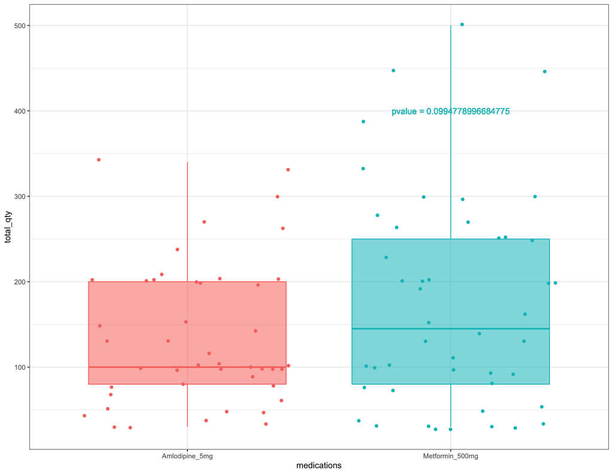

```r
data %>% filter(medications  %in% c("Amlodipine_5mg", "Metformin_500mg")) %>%
  group_by(medications, Date) %>%
  summarize(total_qty = sum(quantity)) %>%
  ggplot(aes(x = medications, y = total_qty, col = medications))+
  geom_boxplot(aes(fill = medications, alpha = 0.2))+
  geom_jitter()+
  theme_bw()+
  geom_text(aes(x = 2, y = 400,
                label = paste0("pvalue = ", tt.results$p.value)))+
  theme(legend.position = "none")
```

# 5 Other questions you can ask:

How many patients take more than one medication? Is there an increase in usage of X medication due to X event that occured in Sept? How much of a particular medication is being given out weekly?